# RLS Modelling for Amanda

Alec

30 January, 2025

# Modelling

## Ecology models

### Red Turban Snail Ecology Models

#### Model 1: Ecology model on the snail counts with temperature, openness, and bottom type

```r
ecology_snail_mod <- gam(log(Turban_Snails + 1) ~ s(sst_scale)+
                               s(norm_openness_scale)+
                           dominant_score,
                                # s(region1, bs = "re"), #Random effect of region does not have an impact on the snails
                             data = env_mod_data,
                             family = gaussian(link = "identity"),
                             method = "REML",
                             select = TRUE)
```

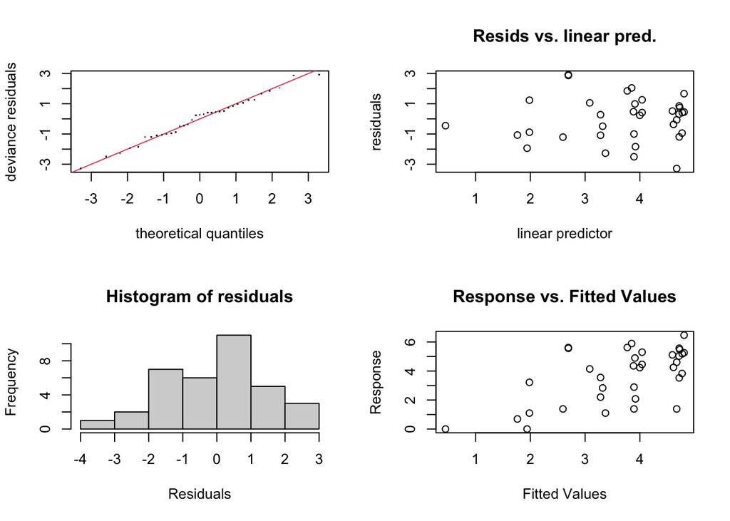

```
##
## Method: REML   Optimizer: outer newton
## full convergence after 12 iterations.
## Gradient range [-8.192637e-06,5.470485e-06]
## (score 64.57123 & scale 2.270256).
## Hessian positive definite, eigenvalue range [1.742853e-07,16.51402].
## Model rank =  20 / 20
##
## Basis dimension (k) checking results. Low p-value (k-index<1) may
## indicate that k is too low, especially if edf is close to k'.
##
##                              k'      edf k-index p-value
## s(sst_scale)           9.00e+00 2.02e-05    0.92    0.27
## s(norm_openness_scale) 9.00e+00 9.49e-01    0.97    0.33
```

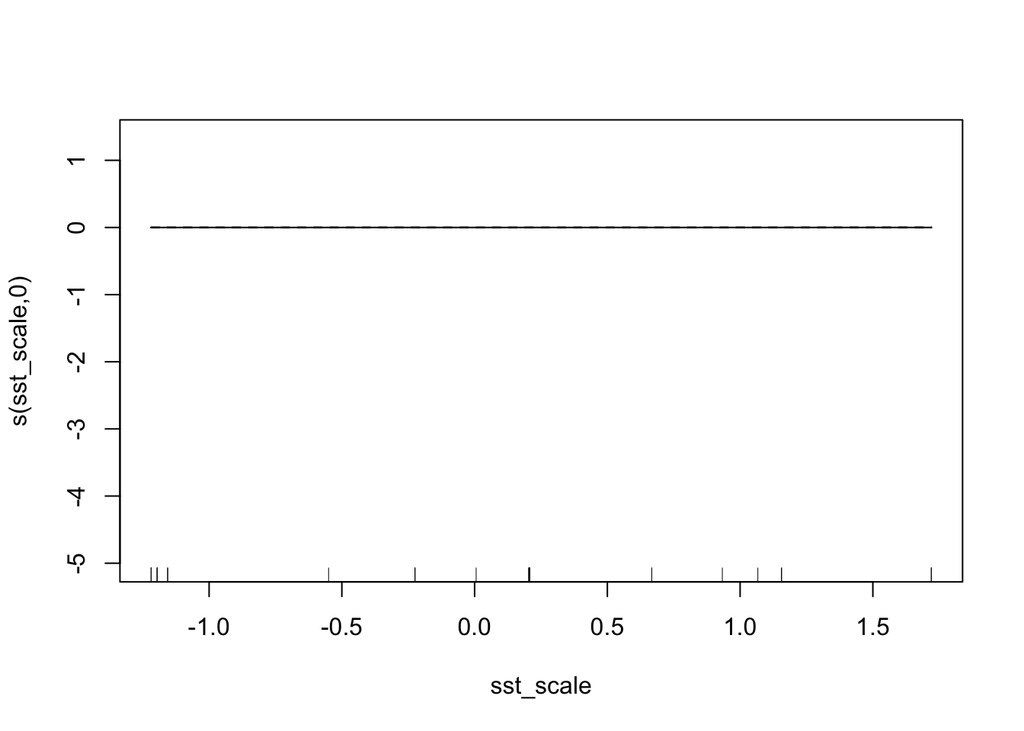

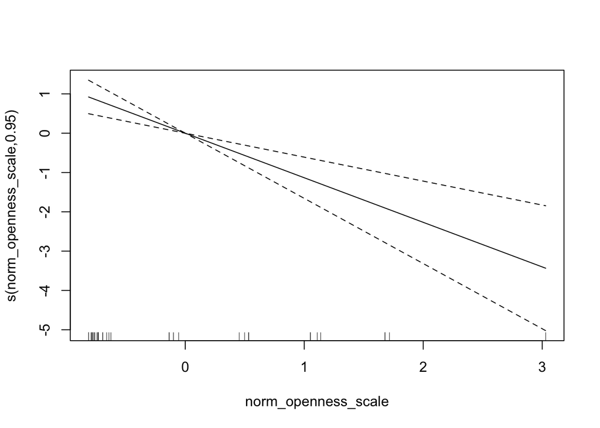

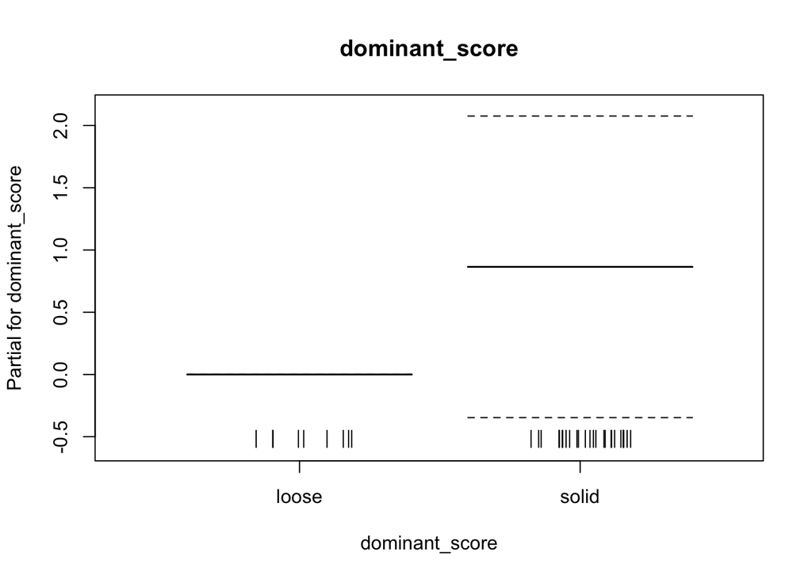

```
##
## Family: gaussian
## Link function: identity
##
## Formula:
## log(Turban_Snails + 1) ~ s(sst_scale) + s(norm_openness_scale) +
##     dominant_score
##
## Parametric coefficients:
##                     Estimate Std. Error t value Pr(>|t|)
## (Intercept)           3.0209     0.5170   5.843  1.7e-06 ***
## dominant_scoresolid   0.8647     0.6057   1.428    0.163
## ---
## Signif. codes:  0 '***' 0.001 '**' 0.01 '*' 0.05 '.' 0.1 ' ' 1
##
## Approximate significance of smooth terms:
##                              edf Ref.df     F  p-value
## s(sst_scale)           2.024e-05      9 0.000 0.745531
## s(norm_openness_scale) 9.493e-01      9 2.078 0.000101 ***
## ---
## Signif. codes:  0 '***' 0.001 '**' 0.01 '*' 0.05 '.' 0.1 ' ' 1
##
## R-sq.(adj) =  0.343   Deviance explained = 38.1%
## -REML = 64.571  Scale est. = 2.2703    n = 35
```

Initially did this model with openness as a smooth term but fitting produced a linear effect of openness so re fit model with linear openness.

##### Testing the residuals for autocorrelation

```
##
##  Moran I test under randomisation
##
## data:  residuals_ecology_snail_mod
## weights: lw
## n reduced by no-neighbour observations
##
## Moran I statistic standard deviate = 1.0542, p-value = 0.2918
## alternative hypothesis: two.sided
## sample estimates:
## Moran I statistic       Expectation          Variance
##        0.28283621       -0.05882353        0.10502790
```

```
##
##  Moran I test under randomisation
##
## data:  residuals_ecology_snail_mod
## weights: lw_inverse
##
## Moran I statistic standard deviate = 1.9113, p-value = 0.05597
## alternative hypothesis: two.sided
## sample estimates:
## Moran I statistic       Expectation          Variance
##        0.29654949       -0.02941176        0.02908670
```

No autocorrelation for both methods when using a two sided test.

##### Testing the model for concurvity

```
## $worst
##                                para s(sst_scale) s(norm_openness_scale)
## para                   1.000000e+00 4.176841e-24           1.365142e-17
## s(sst_scale)           4.173961e-24 1.000000e+00           9.527043e-01
## s(norm_openness_scale) 1.365141e-17 9.527043e-01           1.000000e+00
##
## $observed
##                                para s(sst_scale) s(norm_openness_scale)
## para                   1.000000e+00 1.283340e-30           9.533786e-34
## s(sst_scale)           4.173961e-24 1.000000e+00           4.675591e-01
## s(norm_openness_scale) 1.365141e-17 4.344995e-01           1.000000e+00
##
## $estimate
##                                para s(sst_scale) s(norm_openness_scale)
## para                   1.000000e+00 9.168891e-28           2.363901e-21
## s(sst_scale)           4.173961e-24 1.000000e+00           4.716431e-01
## s(norm_openness_scale) 1.365141e-17 4.621752e-01           1.000000e+00
```

```
##              para s(sst_scale) s(norm_openness_scale)
## worst    0.864154    0.9530676              0.9529587
## observed 0.864154    0.4361814              0.5114618
## estimate 0.864154    0.4931624              0.5009083
```

Temperature and openness seem to be somewhat concurve. Temp having no impact on the model (being removed by select).

#### Model 2: Ecology model on the snail counts with temperature, openness, and bottom type (linear openness)

```r
ecology_snail_mod_linear <- gam(log(Turban_Snails + 1) ~ s(sst_scale)+
                               norm_openness_scale +
                           dominant_score,
                                #s(region1, bs = "re"), #Random effect of region does not have an impact on the snails
                             data = env_mod_data,
                             family = gaussian(link = "identity"),
                             method = "REML",
                             select = TRUE)
```

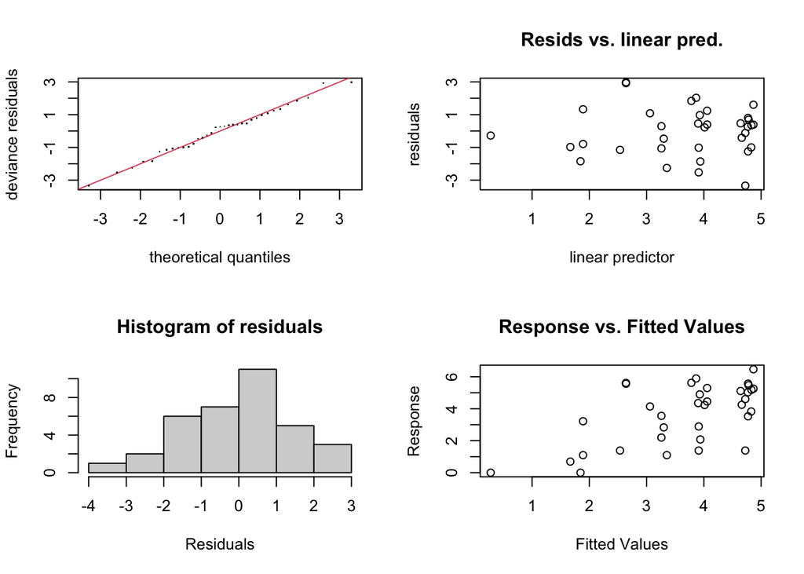

```
##
## Method: REML   Optimizer: outer newton
## full convergence after 10 iterations.
## Gradient range [-1.740135e-05,5.557029e-06]
## (score 62.97458 & scale 2.270256).
## Hessian positive definite, eigenvalue range [7.261404e-07,15.99999].
## Model rank =  12 / 12
##
## Basis dimension (k) checking results. Low p-value (k-index<1) may
## indicate that k is too low, especially if edf is close to k'.
##
##                    k'      edf k-index p-value
## s(sst_scale) 9.00e+00 4.74e-05    0.93    0.27
```

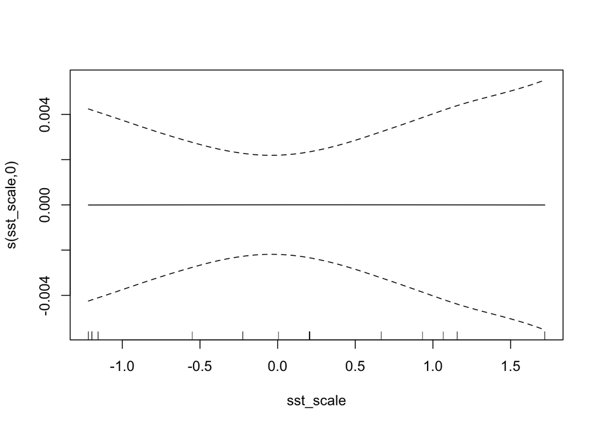

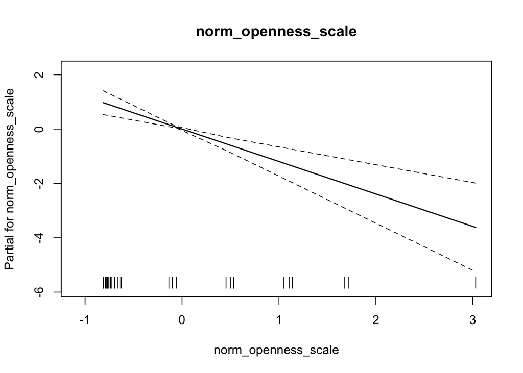

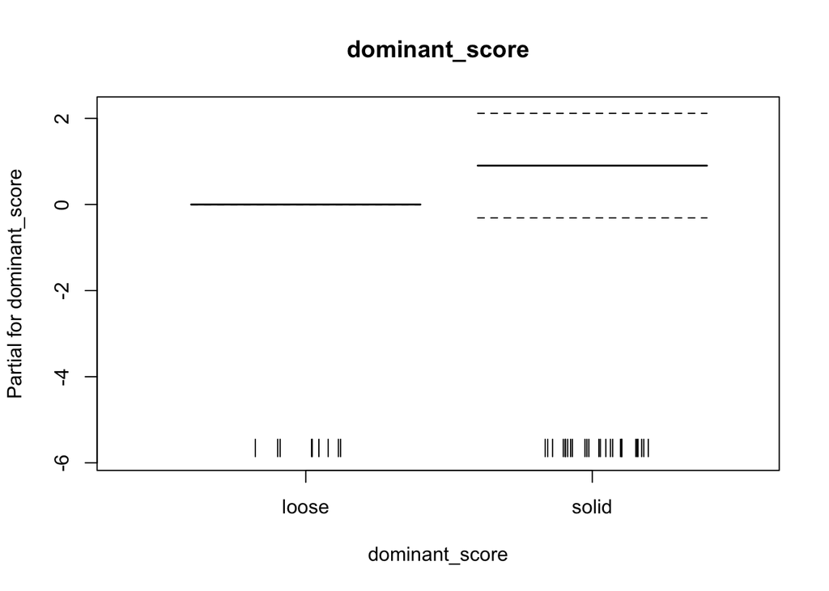

```
##
## Family: gaussian
## Link function: identity
##
## Formula:
## log(Turban_Snails + 1) ~ s(sst_scale) + norm_openness_scale +
##     dominant_score
##
## Parametric coefficients:
##                     Estimate Std. Error t value Pr(>|t|)
## (Intercept)           2.9926     0.5178   5.780 2.06e-06 ***
## norm_openness_scale  -1.1945     0.2691  -4.439 0.000101 ***
## dominant_scoresolid   0.9029     0.6069   1.488 0.146595
## ---
## Signif. codes:  0 '***' 0.001 '**' 0.01 '*' 0.05 '.' 0.1 ' ' 1
##
## Approximate significance of smooth terms:
##                    edf Ref.df F p-value
## s(sst_scale) 4.737e-05      9 0   0.784
##
## R-sq.(adj) =  0.343   Deviance explained = 38.2%
## -REML = 62.975  Scale est. = 2.2703    n = 35
```

Results showing the same trends with normalized openness included as a linear term. Ultimately the results of the environmental model for turban snail abundance/counts indicate the turban snails are not controlled by temperature or substrate type, but they are strongly controlled by the openness gradient, with less snails in more exposed sites.

##### Testing the residuals for autocorrelation

```
##
##  Moran I test under randomisation
##
## data:  residuals_ecology_snail_mod_linear
## weights: lw
## n reduced by no-neighbour observations
##
## Moran I statistic standard deviate = 1.0933, p-value = 0.2743
## alternative hypothesis: two.sided
## sample estimates:
## Moran I statistic       Expectation          Variance
##        0.29408282       -0.05882353        0.10419893
```

```
##
##  Moran I test under randomisation
##
## data:  residuals_ecology_snail_mod_linear
## weights: lw_inverse
##
## Moran I statistic standard deviate = 1.9598, p-value = 0.05002
## alternative hypothesis: two.sided
## sample estimates:
## Moran I statistic       Expectation          Variance
##        0.30424482       -0.02941176        0.02898616
```

No autocorrelation for both methods when using a two sided test.

##### Testing the model for concurvity

```
## $worst
##                      para s(sst_scale)
## para         1.000000e+00 4.176841e-24
## s(sst_scale) 4.162202e-24 1.000000e+00
##
## $observed
##                      para s(sst_scale)
## para         1.000000e+00 4.367291e-31
## s(sst_scale) 4.162202e-24 1.000000e+00
##
## $estimate
##                      para s(sst_scale)
## para         1.000000e+00 9.168891e-28
## s(sst_scale) 4.162202e-24 1.000000e+00
```

```
##               para s(sst_scale)
## worst    0.8032291    0.4731311
## observed 0.8032291    0.1134194
## estimate 0.8032291    0.1317249
```

Concurvity seems to be improved when having openness as a linear term. Maybe not and it is just how the function calculates it differently or omits it.

### Red Sea urchin ecology models

#### Model 3: Ecology model on the urchin counts with temperature, openness, and bottom type

```r
ecology_urchin_mod <- gam(Urchins ~ s(sst_scale)+
                               s(norm_openness_scale)+
                           dominant_score,
                                #s(region1, bs = "re"),
                             data = env_mod_data,
                             family = gaussian(link = "identity"),
                             method = "REML",
                             select = TRUE)
```

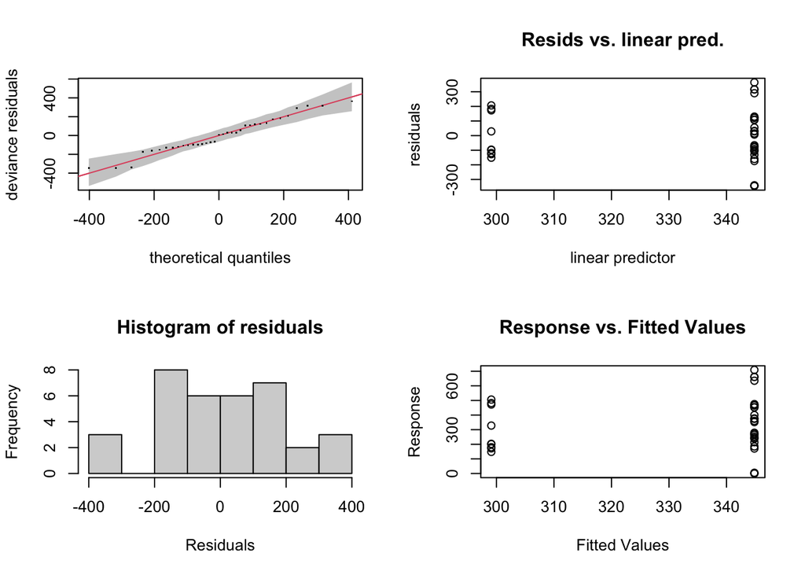

```
##
## Method: REML   Optimizer: outer newton
## full convergence after 11 iterations.
## Gradient range [-1.904191e-05,1.410639e-05]
## (score 222.0236 & scale 34640.64).
## Hessian positive definite, eigenvalue range [8.136318e-07,16.49999].
## Model rank =  20 / 20
##
## Basis dimension (k) checking results. Low p-value (k-index<1) may
## indicate that k is too low, especially if edf is close to k'.
##
##                              k'      edf k-index p-value
## s(sst_scale)           9.00e+00 4.70e-05    0.81    0.11
## s(norm_openness_scale) 9.00e+00 9.15e-05    0.70    0.01 **
## ---
## Signif. codes:  0 '***' 0.001 '**' 0.01 '*' 0.05 '.' 0.1 ' ' 1
```

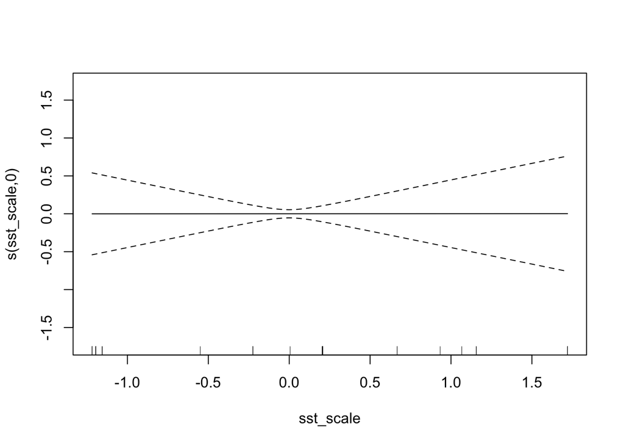

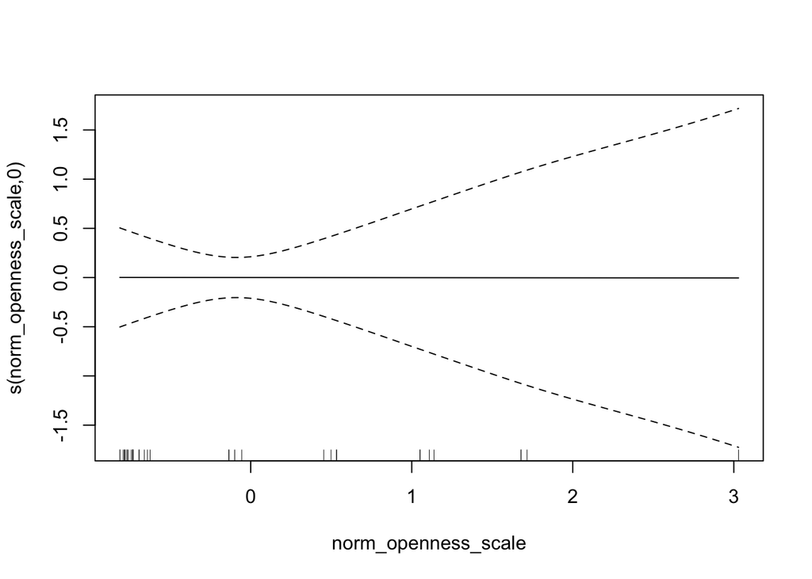

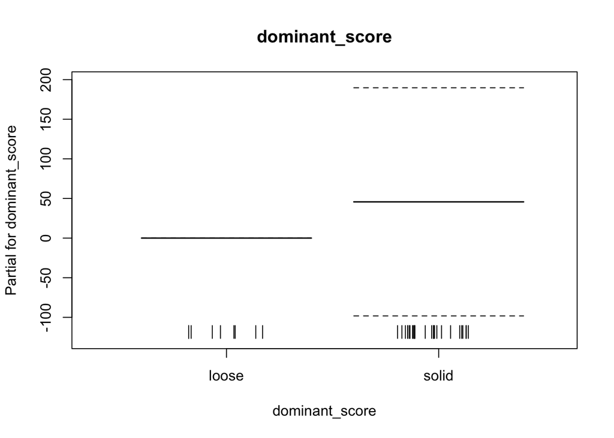

```
##
## Family: gaussian
## Link function: identity
##
## Formula:
## Urchins ~ s(sst_scale) + s(norm_openness_scale) + dominant_score
##
## Parametric coefficients:
##                     Estimate Std. Error t value Pr(>|t|)
## (Intercept)           299.11      62.04   4.821 3.12e-05 ***
## dominant_scoresolid    45.74      71.98   0.635     0.53
## ---
## Signif. codes:  0 '***' 0.001 '**' 0.01 '*' 0.05 '.' 0.1 ' ' 1
##
## Approximate significance of smooth terms:
##                              edf Ref.df F p-value
## s(sst_scale)           4.700e-05      9 0   0.707
## s(norm_openness_scale) 9.153e-05      9 0   0.724
##
## R-sq.(adj) =  -0.0179   Deviance explained = 1.21%
## -REML = 222.02  Scale est. = 34641     n = 35
```

```
##
##  Shapiro-Wilk normality test
##
## data:  ecology_urchin_mod$residuals
## W = 0.96335, p-value = 0.2874
```

Tried with other distributions as well but gaussian appears to be the best. Confirm this with Amanda.

##### Testing the residuals for autocorrelation

```
##
##  Moran I test under randomisation
##
## data:  residuals_ecology_urchin_mod
## weights: lw
## n reduced by no-neighbour observations
##
## Moran I statistic standard deviate = 1.3937, p-value = 0.1634
## alternative hypothesis: two.sided
## sample estimates:
## Moran I statistic       Expectation          Variance
##        0.39519394       -0.05882353        0.10612255
```

```
##
##  Moran I test under randomisation
##
## data:  residuals_ecology_urchin_mod
## weights: lw_inverse
##
## Moran I statistic standard deviate = 2.5621, p-value = 0.0104
## alternative hypothesis: two.sided
## sample estimates:
## Moran I statistic       Expectation          Variance
##        0.40854499       -0.02941176        0.02921946
```

Some positive autocorrelation but only with the inverse distance method. The neighbour method has no autocorrelation.

##### Testing the model for concurvity

```
## $worst
##                                para s(sst_scale) s(norm_openness_scale)
## para                   1.000000e+00 4.176841e-24           1.365142e-17
## s(sst_scale)           4.173961e-24 1.000000e+00           9.527043e-01
## s(norm_openness_scale) 1.365141e-17 9.527043e-01           1.000000e+00
##
## $observed
##                                para s(sst_scale) s(norm_openness_scale)
## para                   1.000000e+00 7.455116e-32           1.158212e-24
## s(sst_scale)           4.173961e-24 1.000000e+00           4.929204e-01
## s(norm_openness_scale) 1.365141e-17 4.803164e-01           1.000000e+00
##
## $estimate
##                                para s(sst_scale) s(norm_openness_scale)
## para                   1.000000e+00 9.168891e-28           2.363901e-21
## s(sst_scale)           4.173961e-24 1.000000e+00           4.716431e-01
## s(norm_openness_scale) 1.365141e-17 4.621752e-01           1.000000e+00
```

```
##              para s(sst_scale) s(norm_openness_scale)
## worst    0.864154    0.9530676              0.9529587
## observed 0.864154    0.5167008              0.5334180
## estimate 0.864154    0.4931624              0.5009083
```

Concurvity is high for temperature and openness. Both are being removed by the double penalty.

#### Model 4: Ecology model on the urchin counts with temperature, openness, and bottom type (random effect of region)

```r
ecology_urchin_mod_re <- gam(Urchins ~ s(sst_scale)+
                               s(norm_openness_scale)+
                           dominant_score+
                                s(region1, bs = "re"),
                             data = env_mod_data,
                             family = gaussian(link = "identity"),
                             method = "REML",
                             select = TRUE)
```

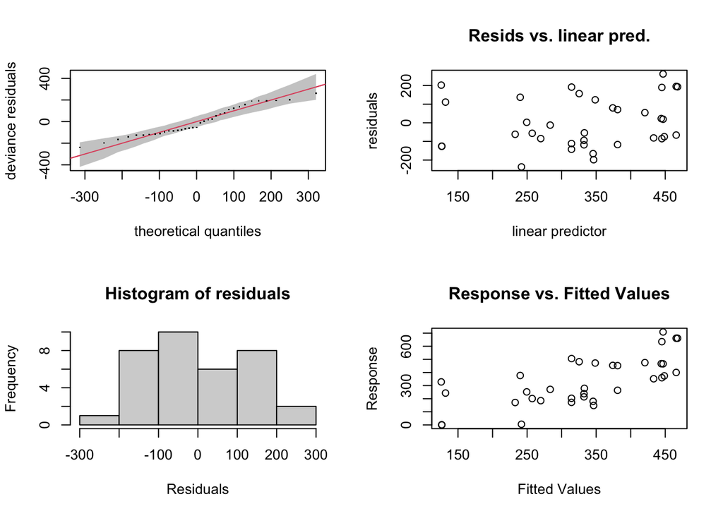

```
##
## Method: REML   Optimizer: outer newton
## full convergence after 9 iterations.
## Gradient range [-0.0001077815,3.170892e-05]
## (score 218.5426 & scale 21137.35).
## Hessian positive definite, eigenvalue range [6.871758e-06,16.63194].
## Model rank =  24 / 24
##
## Basis dimension (k) checking results. Low p-value (k-index<1) may
## indicate that k is too low, especially if edf is close to k'.
##
##                           k'   edf k-index p-value
## s(sst_scale)           9.000 0.401    1.15    0.74
## s(norm_openness_scale) 9.000 1.211    1.00    0.43
## s(region1)             4.000 2.589      NA      NA
```

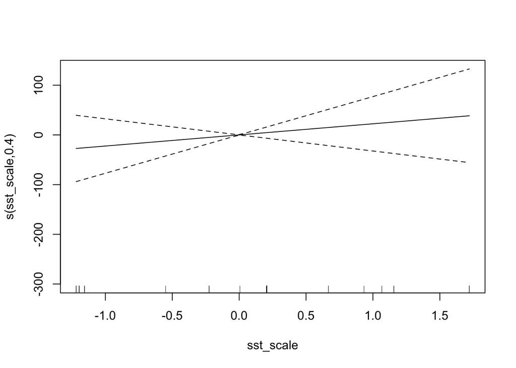

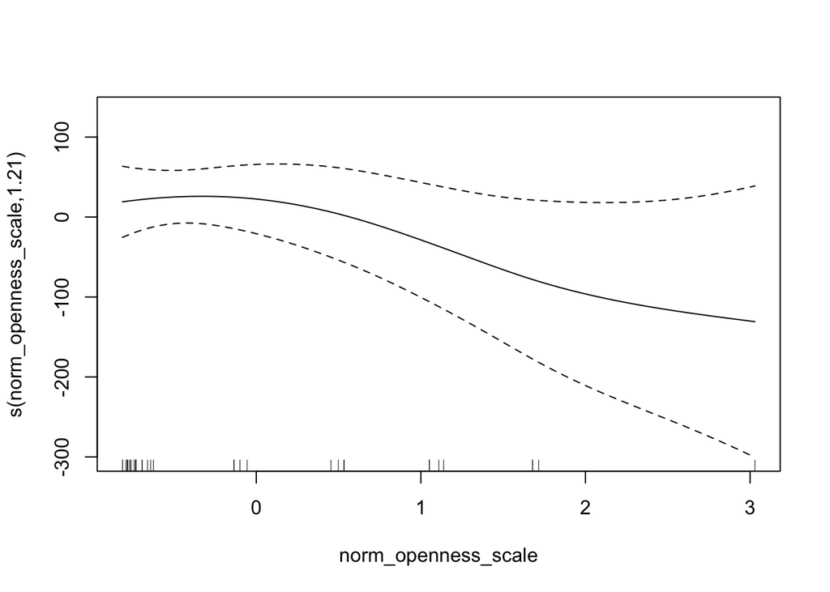

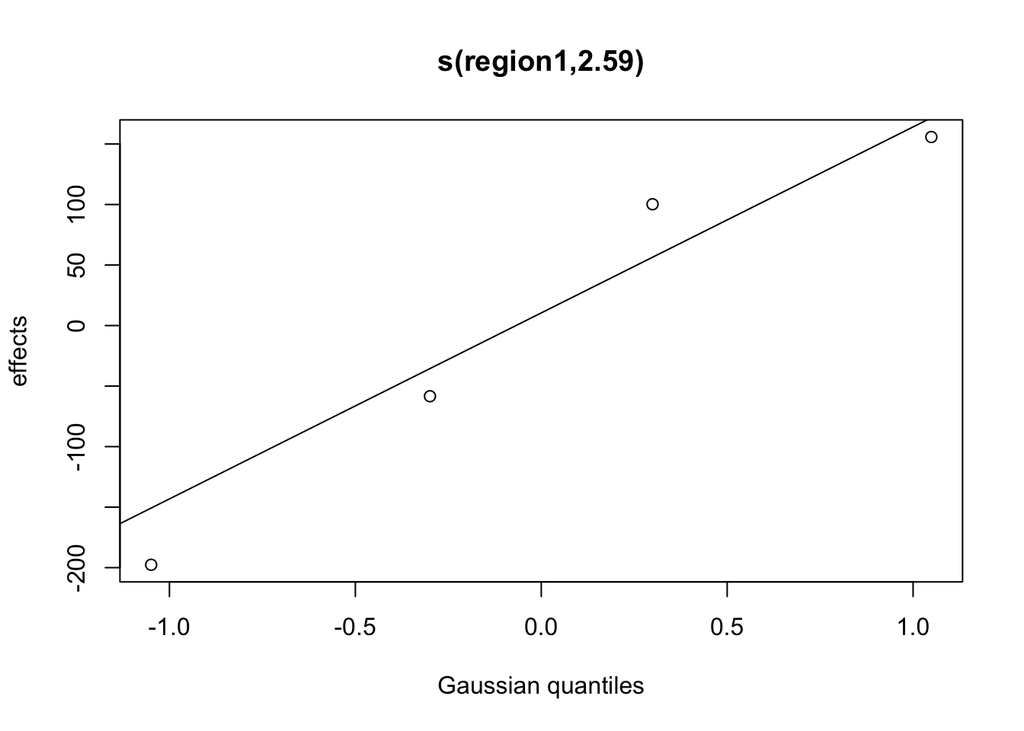

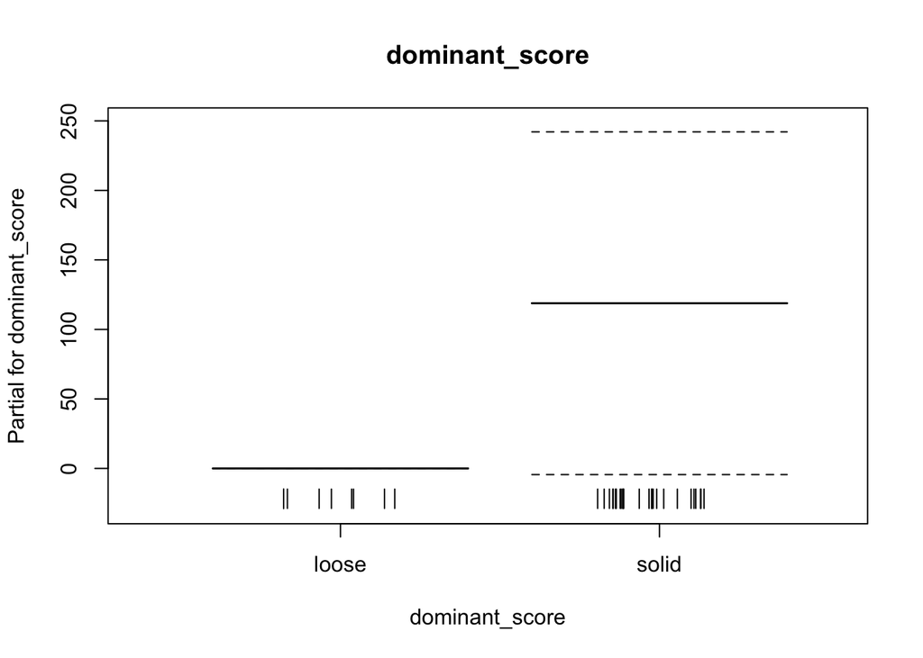

```
##
## Family: gaussian
## Link function: identity
##
## Formula:
## Urchins ~ s(sst_scale) + s(norm_openness_scale) + dominant_score +
##     s(region1, bs = "re")
##
## Parametric coefficients:
##                     Estimate Std. Error t value Pr(>|t|)
## (Intercept)           165.56     104.84   1.579   0.1252
## dominant_scoresolid   118.83      61.63   1.928   0.0638 .
## ---
## Signif. codes:  0 '***' 0.001 '**' 0.01 '*' 0.05 '.' 0.1 ' ' 1
##
## Approximate significance of smooth terms:
##                           edf Ref.df     F  p-value
## s(sst_scale)           0.4009      9 0.484 0.194833
## s(norm_openness_scale) 1.2111      9 0.645 0.085936 .
## s(region1)             2.5891      3 6.765 0.000282 ***
## ---
## Signif. codes:  0 '***' 0.001 '**' 0.01 '*' 0.05 '.' 0.1 ' ' 1
##
## R-sq.(adj) =  0.379   Deviance explained = 47.4%
## -REML = 218.54  Scale est. = 21137     n = 35
```

```
##
##  Shapiro-Wilk normality test
##
## data:  ecology_urchin_mod_re$residuals
## W = 0.94358, p-value = 0.07199
```

Gaussian looks ok. When adding the random effect of region the openness becomes borderline and negative.

##### Testing the residuals for autocorrelation

```
##
##  Moran I test under randomisation
##
## data:  residuals_ecology_urchin_mod_re
## weights: lw
## n reduced by no-neighbour observations
##
## Moran I statistic standard deviate = 0.16268, p-value = 0.8708
## alternative hypothesis: two.sided
## sample estimates:
## Moran I statistic       Expectation          Variance
##      -0.004682036      -0.058823529       0.110760911
```

```
##
##  Moran I test under randomisation
##
## data:  residuals_ecology_urchin_mod_re
## weights: lw_inverse
##
## Moran I statistic standard deviate = -0.047384, p-value = 0.9622
## alternative hypothesis: two.sided
## sample estimates:
## Moran I statistic       Expectation          Variance
##       -0.03758897       -0.02941176        0.02978202
```

No autocorrelation.

##### Testing the model for concurvity

```
## $worst
##                                para s(sst_scale) s(norm_openness_scale)
## para                   1.000000e+00 4.176841e-24           1.365142e-17
## s(sst_scale)           4.173961e-24 1.000000e+00           9.527043e-01
## s(norm_openness_scale) 1.365141e-17 9.527043e-01           1.000000e+00
## s(region1)             1.000000e+00 9.999999e-01           8.933562e-01
##                        s(region1)
## para                    1.0000000
## s(sst_scale)            0.9999999
## s(norm_openness_scale)  0.8933562
## s(region1)              1.0000000
##
## $observed
##                                para s(sst_scale) s(norm_openness_scale)
## para                   1.000000e+00 2.279777e-32           3.768159e-24
## s(sst_scale)           4.173961e-24 1.000000e+00           5.544397e-01
## s(norm_openness_scale) 1.365141e-17 4.832565e-01           1.000000e+00
## s(region1)             1.000000e+00 6.529066e-01           1.186223e-01
##                        s(region1)
## para                    0.3217466
## s(sst_scale)            0.6768175
## s(norm_openness_scale)  0.4895252
## s(region1)              1.0000000
##
## $estimate
##                                para s(sst_scale) s(norm_openness_scale)
## para                   1.000000e+00 9.168891e-28           2.363901e-21
## s(sst_scale)           4.173961e-24 1.000000e+00           4.716431e-01
## s(norm_openness_scale) 1.365141e-17 4.621752e-01           1.000000e+00
## s(region1)             1.000000e+00 6.222112e-01           9.130540e-02
##                        s(region1)
## para                    0.3926531
## s(sst_scale)            0.5771556
## s(norm_openness_scale)  0.2616596
## s(region1)              1.0000000
```

```
##          para s(sst_scale) s(norm_openness_scale) s(region1)
## worst       1    1.0000000              0.9885241  1.0000000
## observed    1    0.8813661              0.6347110  0.9991050
## estimate    1    0.8597655              0.5824720  0.9816727
```

Temp and region are basically fully concurve.

## Fishing models

### Confirming the validity of protection status with DFO flyover data

For the protection status categories, I have grouped them as sites that experience at least a ban on fishing for part of the year as protected and all others as non-protected. This means that the sites that are in the Broken group but are not within the RCA are counted as not protected.

In order to confirm/support our assumptions of which sites are protected, I am using the DFO flyover data to compare the numbers of boats around the different sites.

Based on the boxplots below it seems evident that the protected sites selected are experiencing less fishing pressure and less overall human/boat pressure.

#### Plot indicating which regions protected and non-protected sites are located in

It seems that our current region scheme has no protected sites located within the deer group/bamfield, will need to look into if this is a problem.

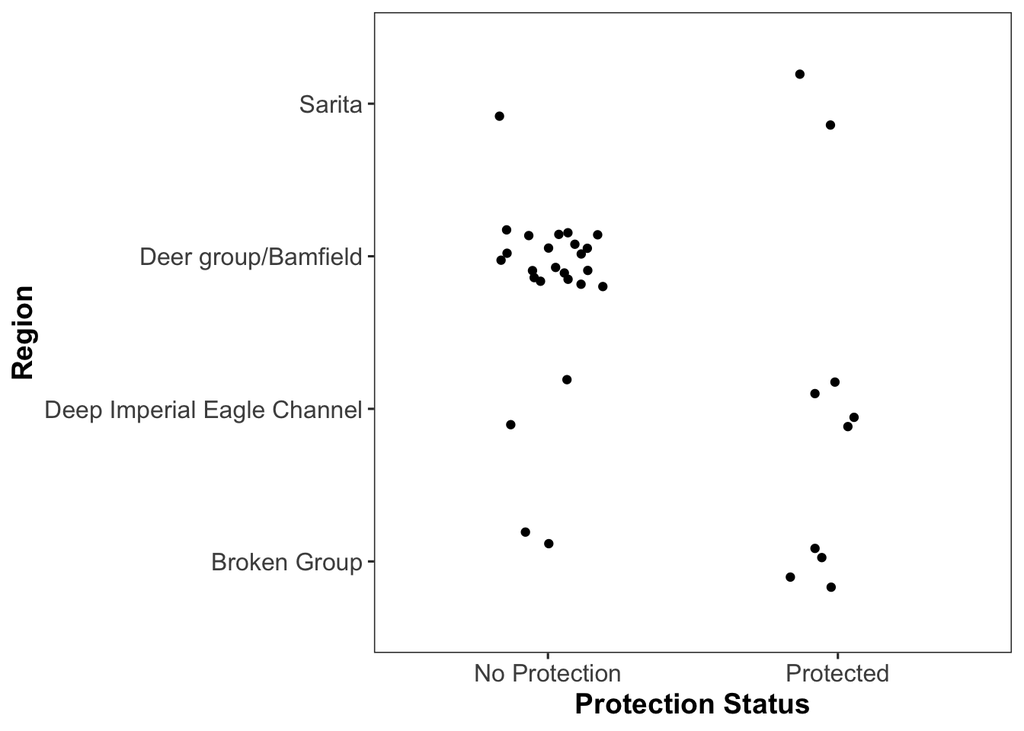

#### Boxplots of rec boat counts between protection levels

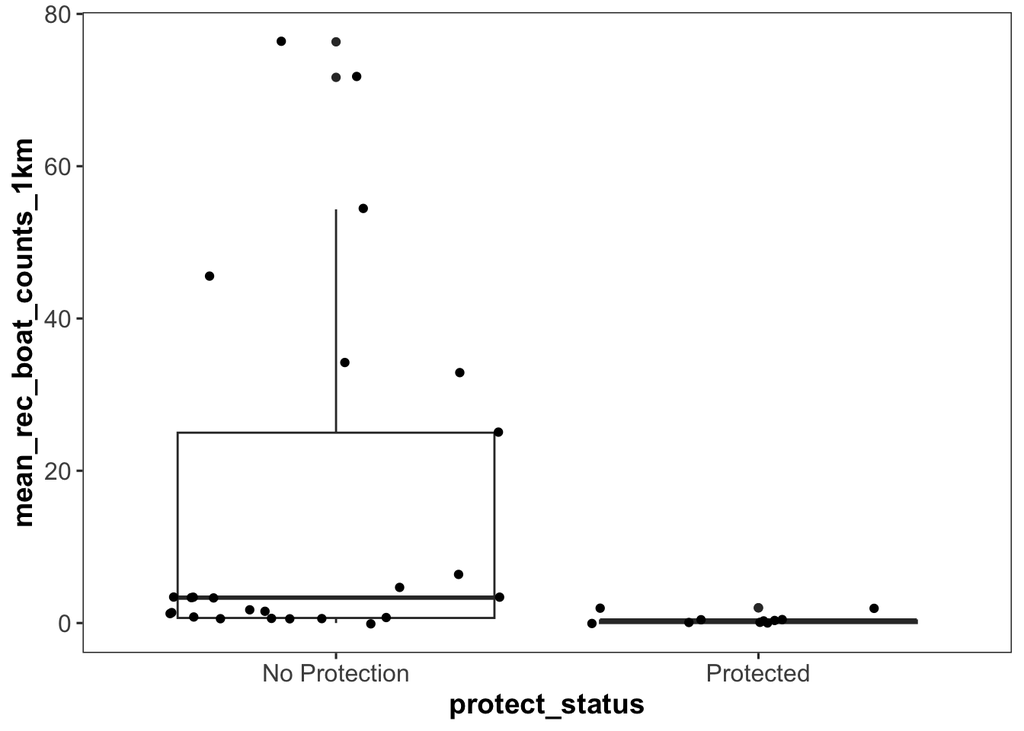

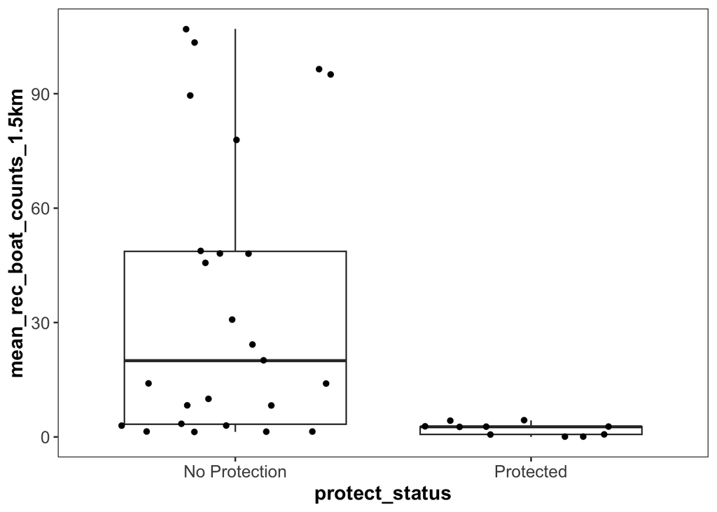

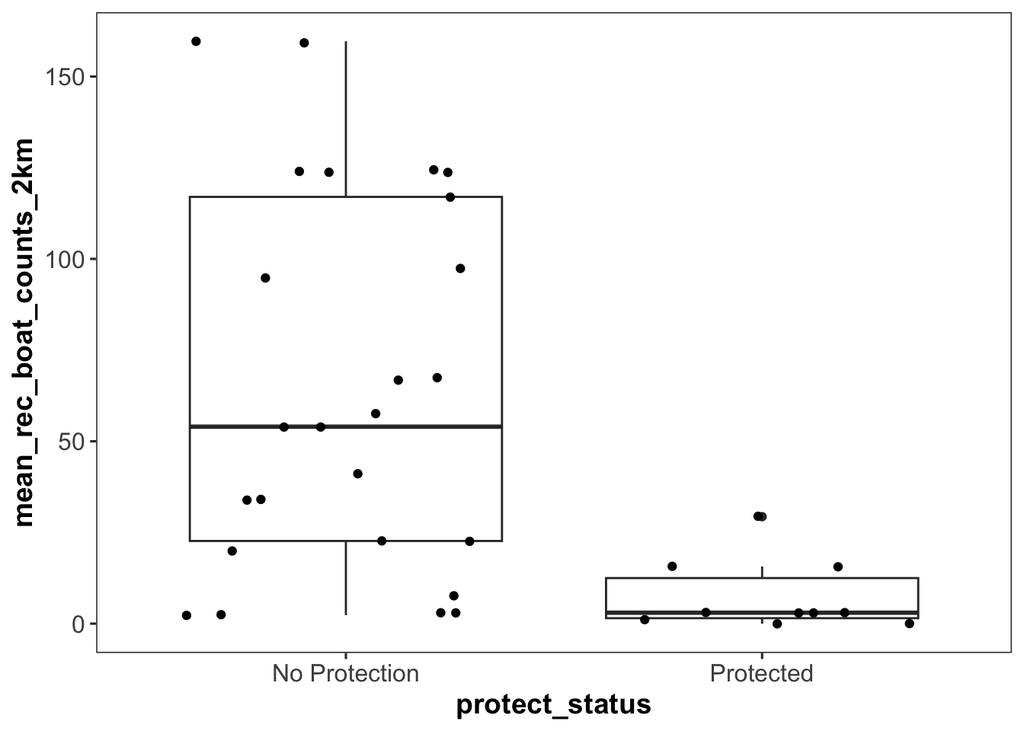

#### Boxplots of total boat counts between protection levels

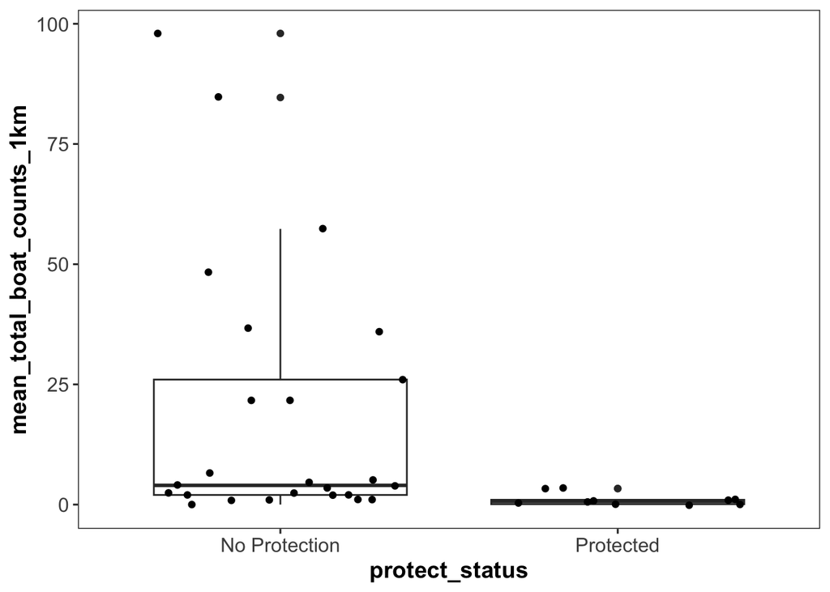

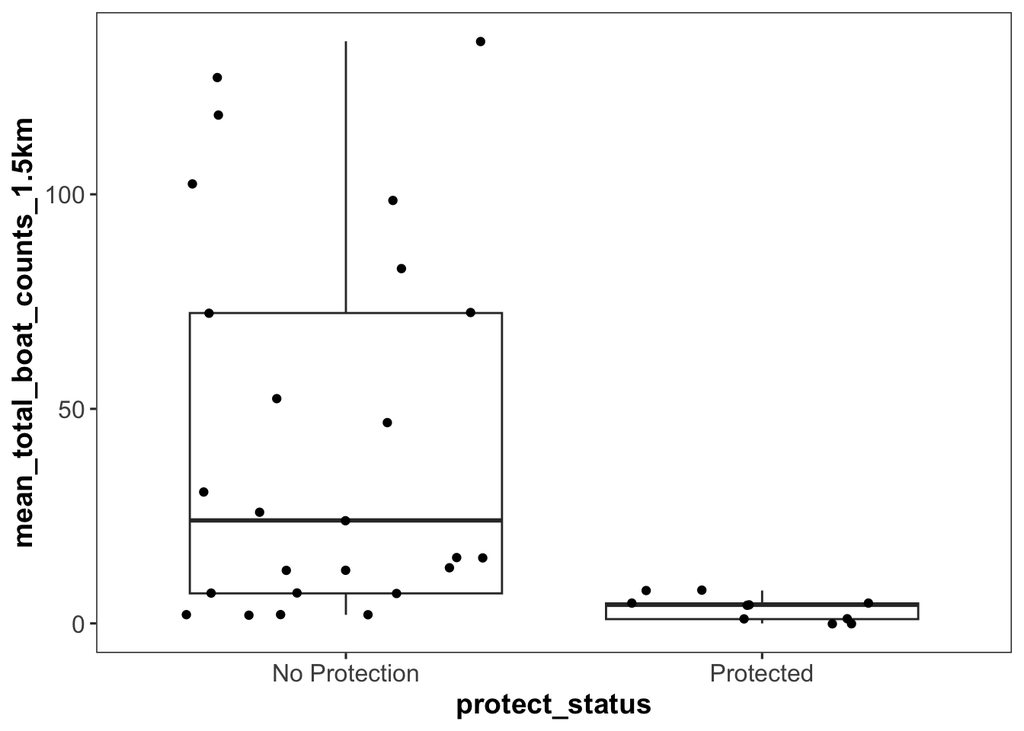

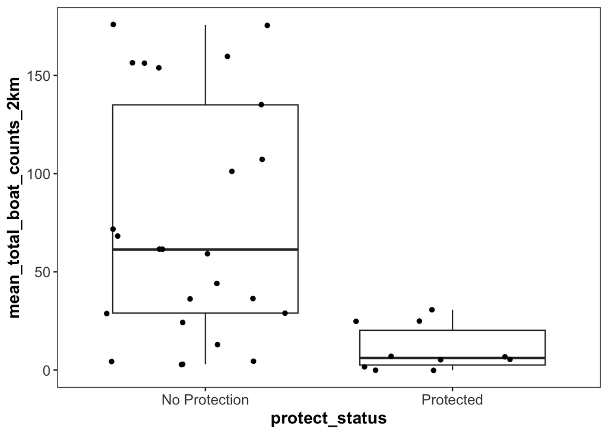

#### Comparing the rec boat counts between sites in the broken group that have been labelled as protected or non-protected

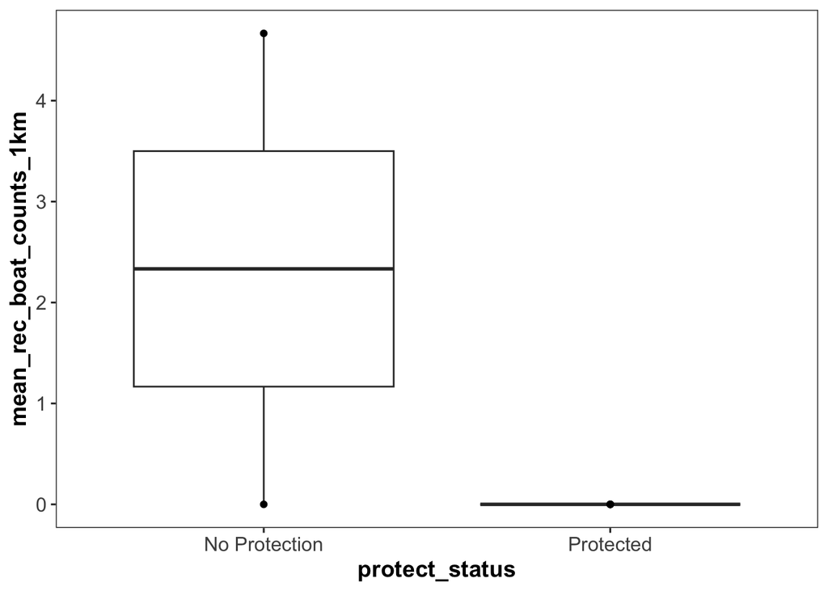

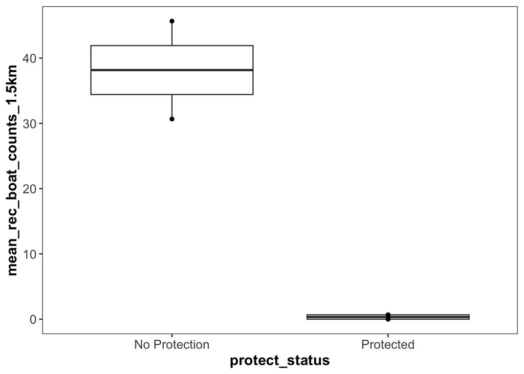

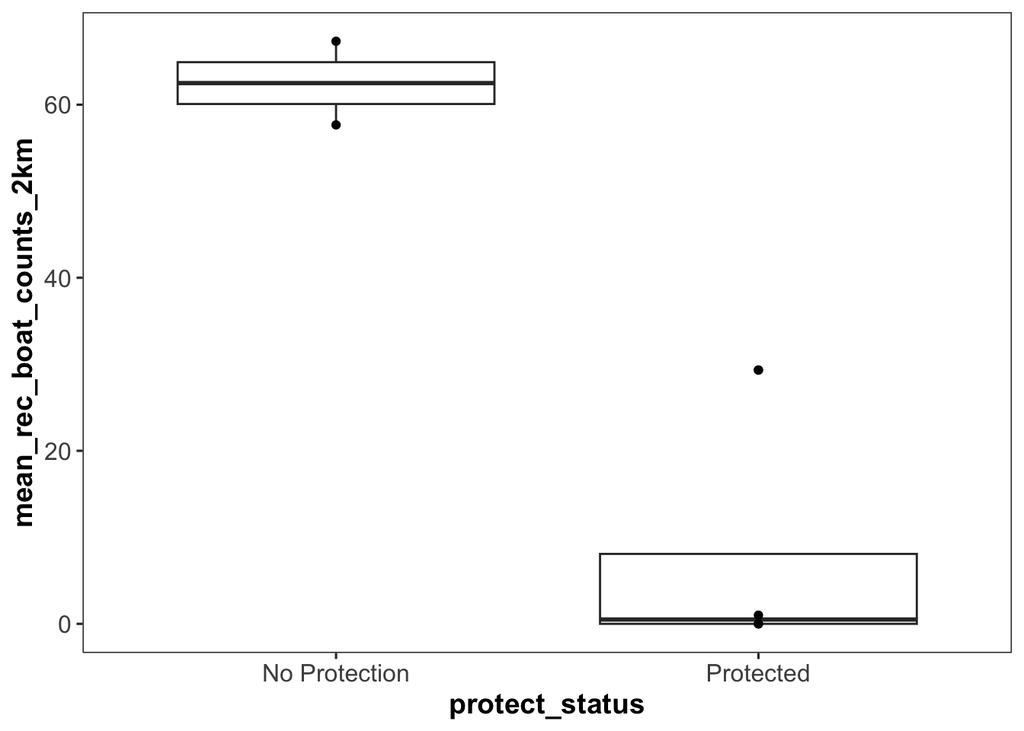

#### Comparing the total boat counts between sites in the broken group that have been labelled as protected or non-protected

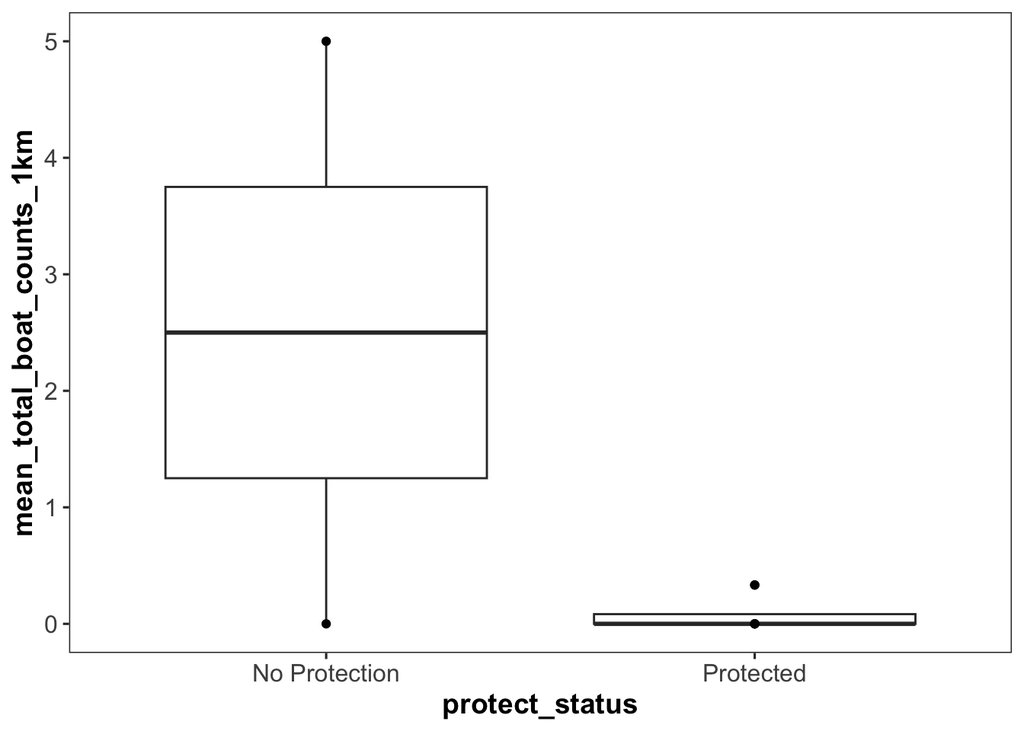

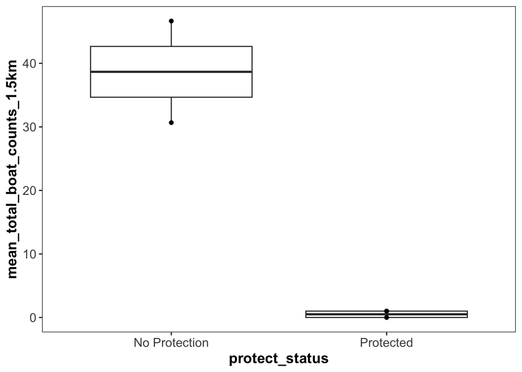

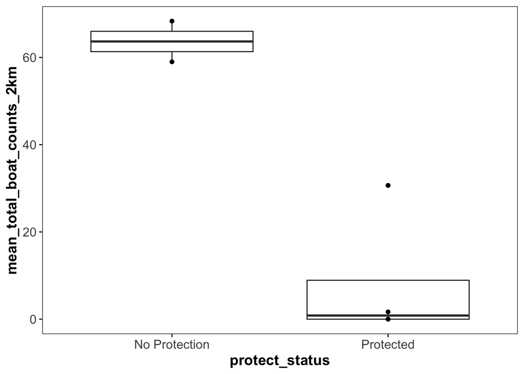

### Red Turban snail fishing models

#### Plotting counts of snails between protected and non-protected

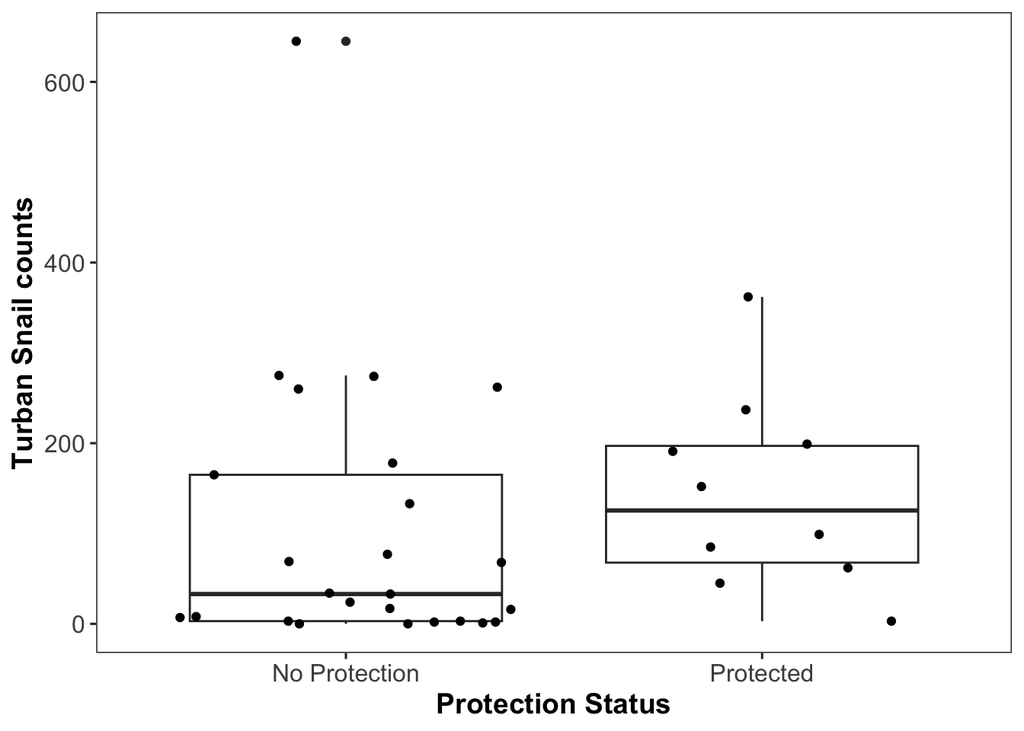

Seeing a weak trend of more snails in the protected sites when compared to the non- protected sites.